# ch05_03_01_model_validation(1)

### 1.1.1 최종 목표를 기억하라

### 1.1.2 이진 분류의 평가지표

##### 1.1.3 다중 분류의 평가지표

##### 1.1.4 회귀의 평가 지표

```python
import pandas as pd
import numpy as np
from sklearn.model_selection import train_test_split
import matplotlib.pyplot as plt
import seaborn as sns
```

### 불균형 데이터 셋

```
dict_keys(['data', 'target', 'frame', 'feature_names', 'target_names', 'images', 'DESCR']) [0 1 2 ... 8 9 8]
[0 1 2 3 4 5 6 7 8 9]
```

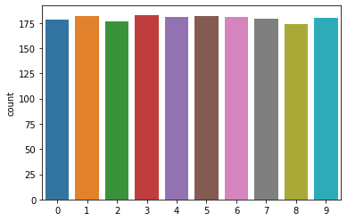

```python
from sklearn.datasets import load_digits

digits = load_digits()
print(digits.keys(), digits.target)
print(np.unique( digits.target ) )
sns.countplot(digits.target)
```

### 타깃이 9:1의 비율을 갖도록 하기

- 9이면 True
- 9가 아니면 False

```python
y = digits.target == 9
```

```python
X_train, X_test, y_train, y_test = train_test_split(
    digits.data, y, random_state=0)
```

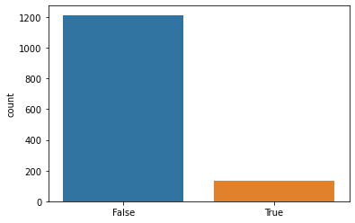

```python
sns.countplot(y_train)
```

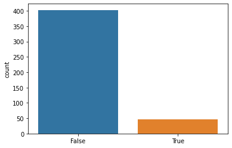

```python
sns.countplot(y_test)
```

### DummyClassifier를 사용한 정확도 계산

- 간단한 룰을 사용하여 예측을 수행한다.
- 실제 문제에서는 사용하지 않으며, 간단한 베이스라인 모델로서 사용된다.

```python
from sklearn.dummy import DummyClassifier
dummy_majority = DummyClassifier(strategy='most_frequent').fit(X_train, y_train)
pred_most_frequent = dummy_majority.predict(X_test)
print("예측된 레이블의 고유값: {}".format(np.unique(pred_most_frequent)))
print("테스트 점수: {:.2f}".format(dummy_majority.score(X_test, y_test)))
```

```
예측된 레이블의 고유값: [False]
테스트 점수: 0.90
```

### 실제 분류기를 사용해보기 - DecisionTreeClassifier

```python
from sklearn.tree import DecisionTreeClassifier
tree = DecisionTreeClassifier(max_depth=2).fit(X_train, y_train)
pred_tree = tree.predict(X_test)
print("테스트 점수: {:.2f}".format(tree.score(X_test, y_test)))
```

```
테스트 점수: 0.92
```

- 실제 분류기와 dummy 분류기와 성능차이가 거의 없다.

### LogisticRegression과의 비교.

- 무작위 선택

```python
from sklearn.linear_model import LogisticRegression

dummy = DummyClassifier().fit(X_train, y_train)
pred_dummy = dummy.predict(X_test)
print("dummy 점수: {:.2f}".format(dummy.score(X_test, y_test)))

logreg = LogisticRegression(C=0.1).fit(X_train, y_train)
pred_logreg = logreg.predict(X_test)
print("logreg 점수: {:.2f}".format(logreg.score(X_test, y_test)))
```

```
dummy 점수: 0.79
logreg 점수: 0.98
```

### 오차행렬(confusion matrix)을 이용하기

```python
import mglearn
```

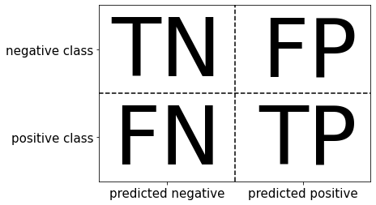

```python
mglearn.plots.plot_binary_confusion_matrix()
```

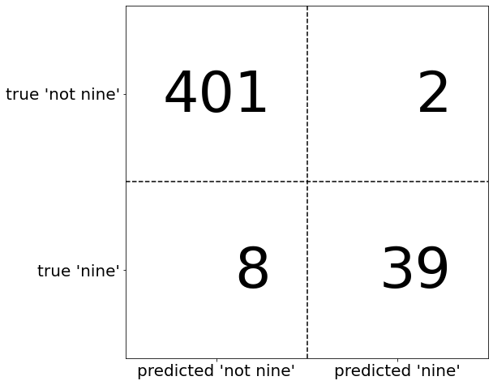

```python
mglearn.plots.plot_confusion_matrix_illustration()
```

```python
from sklearn.metrics import confusion_matrix

confusion = confusion_matrix(y_test, pred_logreg)
print("오차 행렬:\n{}".format(confusion))
```

```
오차 행렬:
[[402   1]
 [  6  41]]
```

### 오차 행렬을 사용한 분류

```python
print("빈도 기반 더미 모델:")
print(confusion_matrix(y_test, pred_most_frequent))

print("\n무작위 더미 모델:")
print(confusion_matrix(y_test, pred_dummy))

print("\n결정 트리:")
print(confusion_matrix(y_test, pred_tree))

print("\n로지스틱 회귀")
print(confusion_matrix(y_test, pred_logreg))
```

```
빈도 기반 더미 모델:
[[403   0]
 [ 47   0]]

무작위 더미 모델:
[[362  41]
 [ 44   3]]

결정 트리:
[[390  13]
 [ 24  23]]

로지스틱 회귀
[[402   1]
 [  6  41]]
```

### 분류의 평가지표를 살펴보자.

- 정확도(accuracy) : 정확하게 예측/전체 예측수
- 정밀도(precision) : 예측을 양성(Positive)으로 한것 전체-TP+FP중.
  - 그중에 얼마나 많은 샘플이 진짜 양성(TP)인가?(양성의 예측도가 좋은가?)
  - TP/(TP+FP)
  - 언제 사용하는가? : 거짓 양성(FP)의 수를 줄일 때 사용
    - 약이 효과 있다고 예측(positive), 하지만 예측 결과가 틀림
    - 암이 아닌데 암이라고 예측
- 재현율(recall) : 실제 데이터의 양성 데이터(TP + FN) 중에
  - 얼마나 많은 샘플을 양성으로 잘 분류했나?(TP)
  - TP/(TP + FN)
  - 재현율이 높아지면 FP는 상대적으로 낮아짐.
  - 언제 사용? FN(음성 예측. 잘못 예측함.)을 줄일 때, 성능 지표로 사용합니다.
    - (암인데 음성(아니라고-Negative)예측하여, 실수. 엄청난 실수 **실제 암인데(Positive)인데, 이를 병원에서 암이 아니다(Negative)**로 예측하면 얼마나 큰일인가?
  - 다른 말로 **민감도(sensitivity), 적중률(hit rate), 진짜 양성 비율(TPR)**이라고 합니다.
- 따라서 병원의 암 예측 같은 경우는 FN를 최소화시켜 재현율을 줄이면, 상대적으로 정밀도를 최대화된다.
- f-score

### 다양한 분류 측정 방법

- https://en.wikipedia.org/wiki/Sensitivity_and_specificity
- 이진 분류에서는 정밀도와 재현율을 가장 많이 사용.
  - 분야마다 다른 지표를 사용할 수 있다.

### F-score

- 정밀도와 재현율을 하나만 가지고 측정이 안된다. 정밀도(precision)와 재현율(recall)의 조화 평균인 f-점수 또는 f-측정은 이 둘을 하나로 요약을 해 줍니다.

### F = 2 x (정밀도*재현율)/(정밀도 + 재현율)

- 다른 말로 F1-score라고 한다.

### 각각의 모델 예측값을 f1-score로 예측

```python
from sklearn.metrics import f1_score

# Dummy분류
print("무작위 더미 모델의 f1 score: {:.2f}".format(f1_score(y_test, pred_dummy)))

# 의사결정트리
print("트리 모델의 f1 score: {:.2f}".format(f1_score(y_test, pred_tree)))

# 로지스틱
print("로지스틱 회귀 모델의 f1 score: {:.2f}".format(
    f1_score(y_test, pred_logreg)))
```

```
무작위 더미 모델의 f1 score: 0.07
트리 모델의 f1 score: 0.55
로지스틱 회귀 모델의 f1 score: 0.92
```

### f1-score를 요약해서 보여주기

- classification_report() : 정밀도, 재현율, f1-score을 모두 한번에 계산
- support는 단순히 샘플의 수

```python
from sklearn.metrics import classification_report
print(classification_report(y_test, pred_most_frequent,
                            target_names=["not 9", "is 9"]))
```

```
              precision    recall  f1-score   support

       not 9       0.90      1.00      0.94       403
        is 9       0.00      0.00      0.00        47

    accuracy                           0.90       450
   macro avg       0.45      0.50      0.47       450
weighted avg       0.80      0.90      0.85       450
```

### dummyClassifier 모델

```python
from sklearn.metrics import classification_report
print(classification_report(y_test, pred_dummy,
                            target_names=["not 9", "is 9"]))
```

```
              precision    recall  f1-score   support

       not 9       0.89      0.90      0.89       403
        is 9       0.07      0.06      0.07        47

    accuracy                           0.81       450
   macro avg       0.48      0.48      0.48       450
weighted avg       0.81      0.81      0.81       450
```

### 로지스틱 회귀

```python
from sklearn.metrics import classification_report
print(classification_report(y_test, pred_logreg,
                            target_names=["not 9", "is 9"]))
```

```
              precision    recall  f1-score   support

       not 9       0.99      1.00      0.99       403
        is 9       0.98      0.87      0.92        47

    accuracy                           0.98       450
   macro avg       0.98      0.93      0.96       450
weighted avg       0.98      0.98      0.98       450
```

### 이진 분류 - 예측을 0,1로 하는 것이 아니라 확률로 해보기

- 400개(음성), 50개(양성) 으로 이루어진 불균형 데이터
- 사용 함수 : decision_function(), predict_proba()
  - decision_function을 0으로, predict_proba를 0.5의 임계값으로 사용

```python
from mglearn.datasets import make_blobs
X, y = make_blobs(n_samples=(400, 50), centers=2, cluster_std=[7.0, 2],
                  random_state=22)

print(X.shape, y.shape)
```

```
(450, 2) (450,)
```

```python
from sklearn.svm import SVC
```

```python
X_train, X_test, y_train, y_test = train_test_split(X, y, random_state=0)
svc = SVC(gamma=.05).fit(X_train, y_train)
```

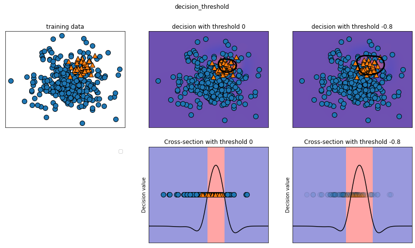

```python
mglearn.plots.plot_decision_threshold()
```

```python
print(classification_report(y_test, svc.predict(X_test)))
```

```
              precision    recall  f1-score   support

           0       0.97      0.89      0.93       104
           1       0.35      0.67      0.46         9

    accuracy                           0.88       113
   macro avg       0.66      0.78      0.70       113
weighted avg       0.92      0.88      0.89       113
```

#### 앞에서 이야기를 했듯 재현율(암인데 잘못 예측할 확률을 낮추어야 한다.)

- 정밀도(precision)을 높이기
  - TP/(TP + NP) : 양성 예측한 것중에 얼마나 잘 예측했나?
- 재현율(recall) : 실제 양성 데이터(TP + FN)중에서 얼마나 많은 샘플이 양성 클래스(TP)로 분류했을까?
- TP/(TP + FN) : 실제 데이터의 양성으로 맞추는 비율
  - 다른 말로 **민감도(sensitivity), 적중률(hit rate), 진짜 양성 비율(TPR)**이라고 합니다.

### 기본 0에서 -0.8로 낮추기

### 재현율(recall)을 높이기

- TP(양성 예측 잘함)을 늘리기, FP(양성 예측)

```python
# 0으로 분류
decision_0 = svc.decision_function(X_test)   > 0
decision_m08 = svc.decision_function(X_test) > -.8

# TP - 잘 맞추는 것을 늘린다.
print("양성을 양성으로 예측(TP) 개수 :", decision_0.sum() )
print("양성을 양성으로 예측(TP) 개수 :", decision_m08.sum() )

# (FP-양성을 잘못 예측하는 것은 줄어듬) 즉 NP는 올라가고 정밀도가 낮아짐
print("양성을 음성예측의(FP) 개수 :", len(decision_0) - decision_0.sum() )
print("양성을 음성예측의(FP) 개수 :", len(decision_m08) - decision_m08.sum()  )
```

[output not shown]

### 임계값을 낮추기(True)을 키우기

```python
y_pred_lower_threshold = svc.decision_function(X_test) > -.8
```

- 정밀도(precision) 0.35에서 0.32로 낮아지고
- 재현율(recall)-sensitivity(민감도)는 0.67에서 1로 올라감.

```python
print(classification_report(y_test, y_pred_lower_threshold))
```

```
              precision    recall  f1-score   support

           0       1.00      0.82      0.90       104
           1       0.32      1.00      0.49         9

    accuracy                           0.83       113
   macro avg       0.66      0.91      0.69       113
weighted avg       0.95      0.83      0.87       113
```

### 기타 방법

- predict_proba()메서드는 출력이 0에서 1 사이로 고정
  - 보통은 0.5를 임계값-이는 양성과 음성이 50%분류이다.
  - 임계값을 높이는 것은 양성이 분류될 확률이 많이 나올 때, 수행